# ScriptTrabajo

Julian Avila-Jimenez

29/8/2020

## Proceso creacion del Buffer

Partimos que ya tienes los registros limpios en un objeto llamado tiburon.x que es el resultado de la limpieza hecha en el paso anterior con la libreria [CoordinateCleanner](https://github.com/ropensci/CoordinateCleaner)

Este objeto lo vamos a convertir en un dataframe para poder trabajar con el

```r
tiburon.x<-read.csv("./tiburon.x.csv")

tiburon.x %>% head(10) #10 primeros registros de la base de datos
```

```
##     X        species decimallongitude decimallatitude
## 1   1 Sphyrna lewini        -82.18286         5.00945
## 2   2 Sphyrna lewini         38.15200       -17.29600
## 3   3 Sphyrna lewini         38.09400       -17.30900
## 4   4 Sphyrna lewini         38.15400       -17.29500
## 5   5 Sphyrna lewini         38.90600       -17.04000
## 6   6 Sphyrna lewini         36.32800       -18.84600
## 7   7 Sphyrna lewini         36.33600       -18.83800
## 8   8 Sphyrna lewini         36.98100       -18.01500
## 9   9 Sphyrna lewini         36.88100       -18.15600
## 10 10 Sphyrna lewini         38.04200       -17.33000
```

```r
class(tiburon.x)
```

```
## [1] "data.frame"
```

```r
tiburon.x <- as.data.frame(tiburon.x)

class(tiburon.x)
```

```
## [1] "data.frame"
```

```r
tiburon.x %>% kable() %>% kable_styling() %>%
  scroll_box(width = "90%", height = "400px")
```

| X | species | decimallongitude | decimallatitude |
| --- | --- | --- | --- |
| 1 | Sphyrna lewini | -82.182861 | 5.0094500 |
| 2 | Sphyrna lewini | 38.152000 | -17.2960000 |
| 3 | Sphyrna lewini | 38.094000 | -17.3090000 |
| 4 | Sphyrna lewini | 38.154000 | -17.2950000 |
| 5 | Sphyrna lewini | 38.906000 | -17.0400000 |
| 6 | Sphyrna lewini | 36.328000 | -18.8460000 |
| 7 | Sphyrna lewini | 36.336000 | -18.8380000 |
| 8 | Sphyrna lewini | 36.981000 | -18.0150000 |
| 9 | Sphyrna lewini | 36.881000 | -18.1560000 |
| 10 | Sphyrna lewini | 38.042000 | -17.3300000 |
| 11 | Sphyrna lewini | 38.136000 | -17.2880000 |
| 12 | Sphyrna lewini | 38.575000 | -17.1160000 |
| 13 | Sphyrna lewini | 38.831000 | -17.0600000 |
| 14 | Sphyrna lewini | 38.158000 | -17.2930000 |
| 15 | Sphyrna lewini | 35.563680 | -23.8527000 |
| 16 | Sphyrna lewini | 35.403290 | -23.8176000 |
| 17 | Sphyrna lewini | 35.392920 | -22.1331700 |
| 18 | Sphyrna lewini | -88.687780 | 29.5141390 |
| 19 | Sphyrna lewini | -81.607592 | 3.9999360 |
| 20 | Sphyrna lewini | -77.750000 | 6.7500000 |
| 21 | Sphyrna lewini | 32.124685 | -28.7853350 |
| 22 | Sphyrna lewini | 38.200000 | -17.5000000 |
| 23 | Sphyrna lewini | 30.262717 | -31.0106500 |
| 24 | Sphyrna lewini | 46.995717 | -25.0391170 |
| 25 | Sphyrna lewini | -28.844068 | -20.4881280 |
| 26 | Sphyrna lewini | -29.310350 | -20.5254170 |
| 27 | Sphyrna lewini | -38.134635 | -19.8487440 |
| 28 | Sphyrna lewini | -47.600000 | -30.5666670 |
| 29 | Sphyrna lewini | -46.166667 | -30.7166670 |
| 30 | Sphyrna lewini | -47.757000 | -28.9031670 |

[output cut: 1516 more lines]

```r
dplyr::glimpse(tiburon.x)
```

```
## Rows: 1,546
## Columns: 4
## $ X                <int> 1, 2, 3, 4, 5, 6, 7, 8, 9, 10, 11, 12, 13, 14, 15,...
## $ species          <chr> "Sphyrna lewini", "Sphyrna lewini", "Sphyrna lewin...
## $ decimallongitude <dbl> -82.18286, 38.15200, 38.09400, 38.15400, 38.90600,...
## $ decimallatitude  <dbl> 5.009450, -17.296000, -17.309000, -17.295000, -17....
```

```r
tiburon.p<- tiburon.x #nuevo objeto para conservar el anterior sin modificacion
```

Vamos a utilizar la libreria [Geobuffer](https://github.com/valentinitnelav/geobuffer) que nos va a permitir crear un buffer geodesico alrededor de los puntos de ocurrencias de un tamaño dado en metros. (Un buffer geodesico no se ve afectado por la distorsion de los sistemas de coordenadas proyectados)

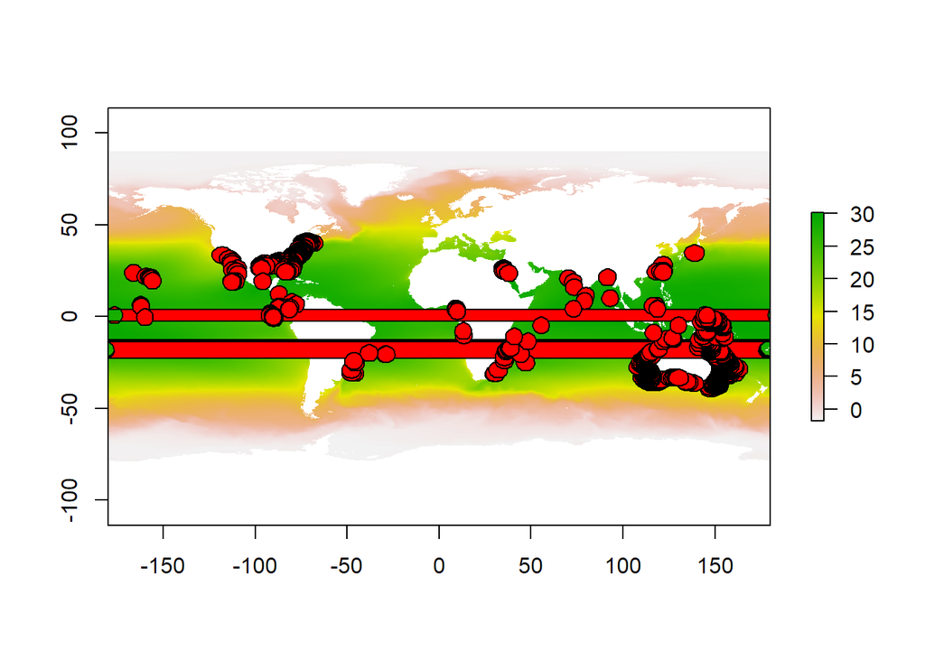

```r
coordinates(tiburon.p) <- ~decimallongitude + decimallatitude

prj <- CRS("+proj=longlat +ellps=WGS84 +datum=WGS84 +no_defs") # the projection string for WGS84

tiburon.p <- SpatialPoints(tiburon.p, proj4string = prj)



#Buffer

#devtools::install_github("valentinitnelav/geobuffer")
library(geobuffer)
pts_buf_500km <- geobuffer_pts(xy = tiburon.p, dist_m = 500*10^3)

#carga de capas ambientales, en esta parte estoy pidiendo a R que lea todos los .asc
#dentro de mi carpeta de capas ambientales, tu deberias reemplazar la ruta

lyTemp<-stack(list.files("C:/Users/julia/Documents/S.lewini/Raster",
                           "*.asc$",full.names = TRUE, recursive = TRUE))

#grafico de la primera capa ambiental
plot(lyTemp[[1]])
#grafico del buffer
plot(pts_buf_500km, col="red", add=T)
```

Debido a que hay registros muy cercanos a los 180 grados de longitud al hacer el buffer se crean unas bandas que afectan el buffer, para solucionar esto vamos a retirar los registros problematicos

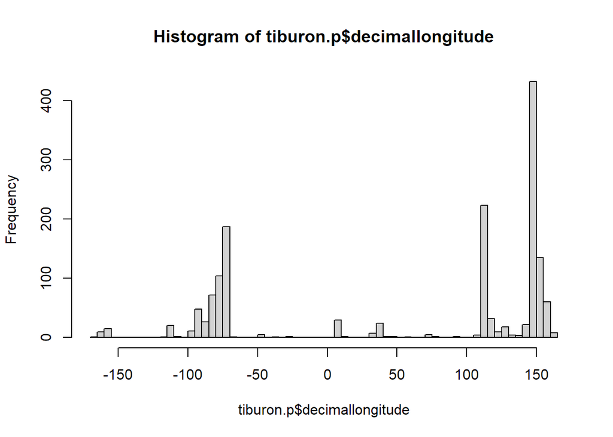

```r
#por esta razon creamos un objeto nuevo, asi podemos llamar al
#anterior como respaldo

tiburon.p<- tiburon.x

#Ahora hacermos el filtrado de ocurrencias

tiburon.p<- tiburon.p %>%
  filter(decimallongitude <178 & decimallongitude>-170)

#un poco de analisis exploratorio...

hist(tiburon.p$decimallongitude, breaks=50)
```

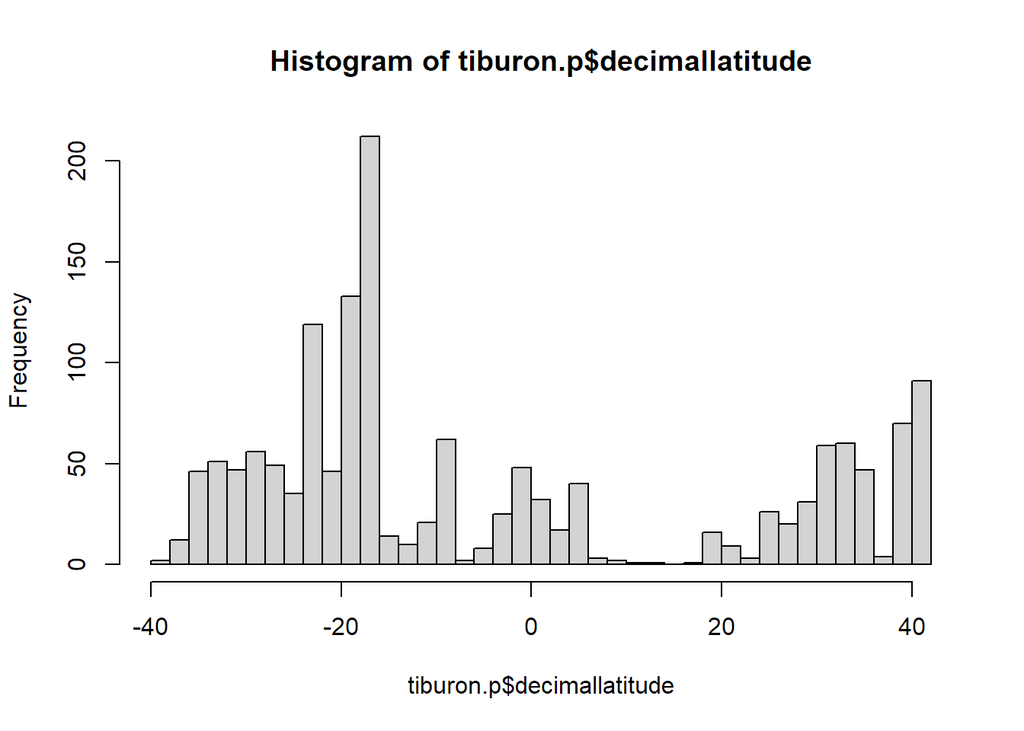

```r
hist(tiburon.p$decimallatitude, breaks=50)
```

```r
min(tiburon.p$decimallongitude)
```

```
## [1] -166.213
```

```r
max(tiburon.p$decimallongitude)
```

```
## [1] 162.75
```

```r
tiburon.p %>%
  kable() %>% kable_styling() %>%
  scroll_box(width = "90%", height = "400px")
```

| X | species | decimallongitude | decimallatitude |
| --- | --- | --- | --- |
| 1 | Sphyrna lewini | -82.182861 | 5.0094500 |
| 2 | Sphyrna lewini | 38.152000 | -17.2960000 |
| 3 | Sphyrna lewini | 38.094000 | -17.3090000 |
| 4 | Sphyrna lewini | 38.154000 | -17.2950000 |
| 5 | Sphyrna lewini | 38.906000 | -17.0400000 |
| 6 | Sphyrna lewini | 36.328000 | -18.8460000 |
| 7 | Sphyrna lewini | 36.336000 | -18.8380000 |
| 8 | Sphyrna lewini | 36.981000 | -18.0150000 |
| 9 | Sphyrna lewini | 36.881000 | -18.1560000 |
| 10 | Sphyrna lewini | 38.042000 | -17.3300000 |
| 11 | Sphyrna lewini | 38.136000 | -17.2880000 |
| 12 | Sphyrna lewini | 38.575000 | -17.1160000 |
| 13 | Sphyrna lewini | 38.831000 | -17.0600000 |
| 14 | Sphyrna lewini | 38.158000 | -17.2930000 |
| 15 | Sphyrna lewini | 35.563680 | -23.8527000 |
| 16 | Sphyrna lewini | 35.403290 | -23.8176000 |
| 17 | Sphyrna lewini | 35.392920 | -22.1331700 |
| 18 | Sphyrna lewini | -88.687780 | 29.5141390 |
| 19 | Sphyrna lewini | -81.607592 | 3.9999360 |
| 20 | Sphyrna lewini | -77.750000 | 6.7500000 |
| 21 | Sphyrna lewini | 32.124685 | -28.7853350 |
| 22 | Sphyrna lewini | 38.200000 | -17.5000000 |
| 23 | Sphyrna lewini | 30.262717 | -31.0106500 |
| 24 | Sphyrna lewini | 46.995717 | -25.0391170 |
| 25 | Sphyrna lewini | -28.844068 | -20.4881280 |
| 26 | Sphyrna lewini | -29.310350 | -20.5254170 |
| 27 | Sphyrna lewini | -38.134635 | -19.8487440 |
| 28 | Sphyrna lewini | -47.600000 | -30.5666670 |
| 29 | Sphyrna lewini | -46.166667 | -30.7166670 |
| 30 | Sphyrna lewini | -47.757000 | -28.9031670 |

[output cut: 1501 more lines]

Creamos el buffer de nuevo esta vez sin registros cercanos a 180 grados

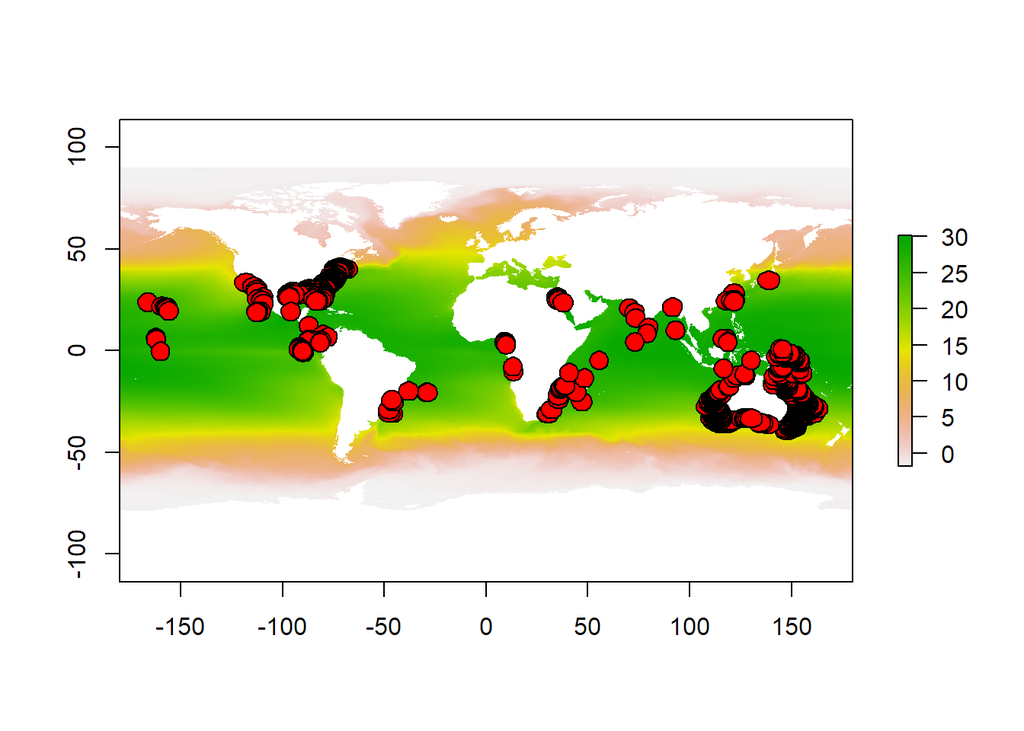

```r
coordinates(tiburon.p) <- ~decimallongitude + decimallatitude

prj <- CRS("+proj=longlat +ellps=WGS84 +datum=WGS84 +no_defs") # the projection string for WGS84

tiburon.p <- SpatialPoints(tiburon.p, proj4string = prj)



#Buffer 500km

#Aqui puedes cambiar el valor a el tama;o de buffer que necesites

#devtools::install_github("valentinitnelav/geobuffer")
library(geobuffer)
pts_buf_500km <- geobuffer_pts(xy = tiburon.p, dist_m = 500*10^3)

#grafico de la primera capa ambiental
plot(lyTemp[[1]])
#grafico del buffer
plot(pts_buf_500km, col="red", add=T)
```

## Area de calibracion M

Ahora si vamos a crear el area de calibracion cortando las capas ambientales al tama;o del buffer creado para cada registro de *S. lewinni*

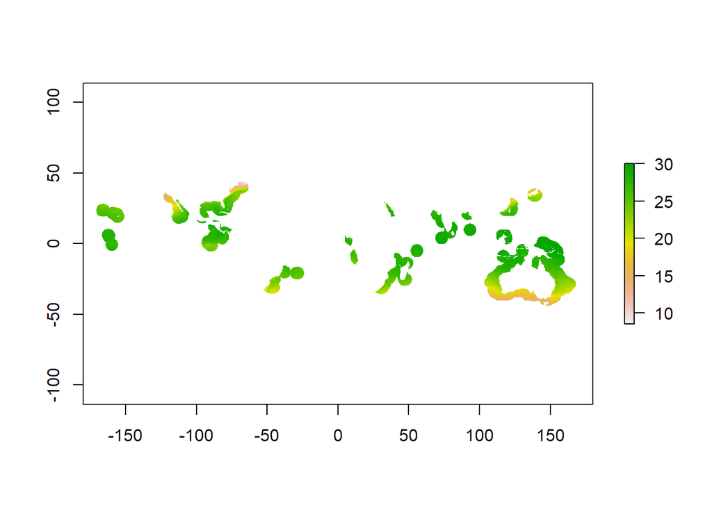

```r
r2 <- crop(lyTemp, extent(pts_buf_500km))
r3 <- mask(lyTemp, pts_buf_500km)
plot(r3$Present.Surface.Temperature.Mean)
```

Luego puedes usar las siguientes lineas de codigo para guardar los raster cortados con el buffer en la carpeta de M_variables

```r
#setwd("./Slewinni/M_variables/Set1")
#writeRaster(r3, filename=names(r3), bylayer=TRUE,format="ascii")
```